# DATA606 Chapter 8 Exercises

John K. Hancock

November 23, 2018

## DATA606 Chapter 8 Exercises

#### 8.2

1. Write the equation of the regression line.

#### Answer

y = 120.07 + -1.93x

2. Interpret the slope in this context, and calculate the predicted birth weight of first borns and others.

#### Answer

The slope in this context means that the baby’s weight will be 120.07 if it’s the first born, and the weight will decrease by 1.93 ounces if it is not the first born. As stated previously, the model predicts that the weight of the first born will be 120.07. If not first born, the model predicts that the birth weight will be 118.14.

#### 8.4

1. Write the equation of the regression line.

#### Answer

absenteeism = 18.93 + -9.11*eth + 3.10*sex + lrn*2.15

2. Interpret each one of the slopes in this context.

#### Answer

For ethnicity, absenteeism descreases if the student is not aboriginal, but increases if the student is aboriginal. For sex, absenteeism increases if the student is male and decreases if it’s female student. For learner, absenteeism increases if the student is a slow learner, and decreases if otherwise.

3. Calculate the residual for the first observation in the data set: a student who is aboriginal, male, a slow learner, and missed 2 days of school.

#### Answer

The residual for the first observation is -22.18.

```r
eth = 0
sex= 1
lrn = 1

absenteeism = 18.93 + (-9.11*eth) + (3.10*sex) + (lrn*2.15)
actual_absence = 2
residual_absence = actual_absence - absenteeism
residual_absence
```

```
## [1] -22.18
```

4. The variance of the residuals is 240.57, and the variance of the number of absent days for all students in the data set is 264.17. Calculate the R2 and the adjusted R2. Note that there are 146 observations in the data set.

#### Answer

The R2 score is 0.08933641 The Adjusted R2 score is 0.07009704

```r
var_residual  = 240.57
var_birth_Weights = 264.17
n = 146
k = 3
R2 = 1 - (var_residual/var_birth_Weights)
Adi_R2 = 1 - ((var_residual * (n-1)) / (var_birth_Weights * (n-k-1)))

R2
```

```
## [1] 0.08933641
```

```r
Adi_R2
```

```
## [1] 0.07009704
```

#### 8.8

Absenteeism, Part II. Exercise 8.4 considers a model that predicts the number of days absent using three predictors: ethnic background (eth), gender (sex), and learner status (lrn). The table below shows the adjusted R-squared for the model as well as adjusted R-squared values for all models we evaluate in the first step of the backwards elimination process. Model Adjusted R2 1 Fullmodel 0.0701 2 No ethnicity -0.0033 3 No sex 0.0676 4 No learner status 0.0723 Which, if any, variable should be removed from the model first?

#### Answer

Backward elimination begins with the largest model and eliminates variables one by- one until we are satisfied that all remaining variables are important to the model. In this context, it would be leaner status that would be removed. This is the variable that contributes the least to the model.

#### 8.16

1. Each column of the table above represents a different shuttle mission. Examine these data and describe what you observe with respect to the relationship between temperatures and damaged O-rings.

#### Answer

Looking at the observations, O-rings are more damaged during lower temperatures than at high temperatures.

#### Answer

The model consist of one predictor, Temperature with an intercept of 11.6630. The p-value of the model is < 0.05 which means that it is statistically significant to reject the Null Hypothesis that temperature has no affect on O-ring damage.

3. Write out the logistic model using the point estimates of the model parameters.

#### Answer

Loge(p1/1-p1) = 11.6630 + -0.2162*Temperature

4. Based on the model, do you think concerns regarding O-rings are justified? Explain.

#### Answer

Yes concerns regarding O-rins are justified. The model does explain that Temperature has an affect on damaged O-rings. Damaged O-rings was seen to be the cause of the disaster.

#### 8.18

Challenger disaster, Part II. Exercise 8.16 introduced us to O-rings that were identified as a plausible explanation for the breakup of the Challenger space shuttle 73 seconds into takeo??? in 1986. The investigation found that the ambient temperature at the time of the shuttle launch was closely related to the damage of O-rings, which are a critical component of the shuttle. See this earlier exercise if you would like to browse the original data.

1. Use the model to calculate the probability that an O-ring will become damaged at each of the following ambient temperatures: 51, 53, and 55 degrees Fahrenheit.

#### Answer

The probabilities of O-ring damage at 51, 53, and 55 degrees Fahrenheit is 0.65, 0.55, and 0.44 respectively,

```r
temperatures = c(51,53,55)
probabilities = exp(11.6630-0.2162*temperatures)/(1+exp(11.6630-0.2162*temperatures))
probabilities
```

```
## [1] 0.6540297 0.5509228 0.4432456
```

```r
#checking the results

round(log((probabilities) / (1-probabilities)),2) == round((11.6630 - (0.2162*temperatures)),2)
```

```
## [1] TRUE TRUE TRUE
```

2. Add the model-estimated probabilities from part (a) on the plot, then connect these dots using a smooth curve to represent the model-estimated probabilities.

#### Answer

```r
library(ggplot2)
temperatures2 <- c(temperatures, 57,59,61,63,65,67,69,71)
probabilities2 <- c(probabilities, 0.341,0.251,0.179, 0.124,0.084,0.056,0.037,0.024)

Shuttle_Data <-as.data.frame(cbind(temperatures2, probabilities2))
Shuttle_Data
```

```
##    temperatures2 probabilities2
## 1             51      0.6540297
## 2             53      0.5509228
## 3             55      0.4432456
## 4             57      0.3410000
## 5             59      0.2510000
## 6             61      0.1790000
## 7             63      0.1240000
## 8             65      0.0840000
## 9             67      0.0560000
## 10            69      0.0370000
## 11            71      0.0240000
```

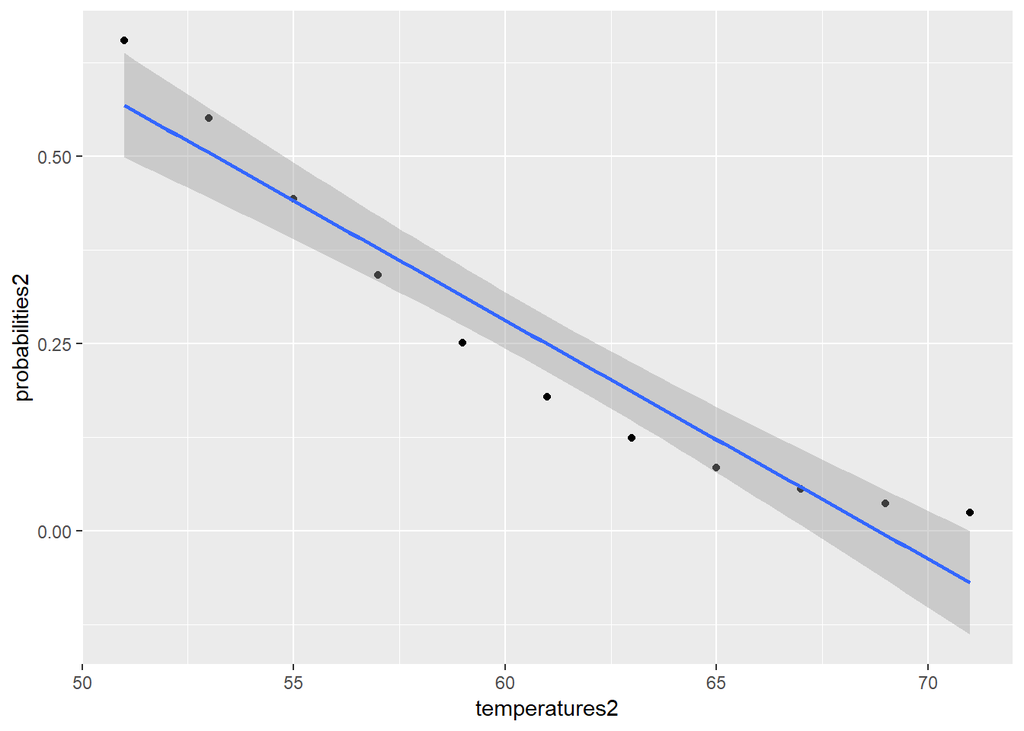

```r
library(ggplot2)
ggplot(Shuttle_Data, aes(x=temperatures2,y=probabilities2)) + geom_point()  +
    stat_smooth(method = 'glm')
```

3. Describe any concerns you may have regarding applying logistic regression in this application, and note any assumptions that are required to accept the model’s validity.

#### Answer

Logistic regression conditions There are two key conditions for fitting a logistic regression model:

1. Each predictor xi is linearly related to logit(pi) if all other predictors are held constant.
2. Each outcome Yi is independent of the other outcomes.

We can assume independence of the observations so the second condition has been met.